# Gapminder

David Kane

9/26/2019

Remember what [we want](http://rpubs.com/dkane/gganimate). You don’t need to do these in order. Work on what you like first. Hints:

1. Let’s first get the plot looking reasonable for one year (1962) and one continent (Europe). Once it does, we can expand to more continents and years.
2. Colors are tricky. Try looking for help about the gapminder package. Does it have some built-in colors that might be useful?
3. Too much opaque overlapping for the datapoints is ugly. Our target has the points as somewhat transparent. How do we achieve that?
4. Our target graphic has no legend, which I think is right. How do we turn off the legend?
5. The target uses data from 3 (?) continents. Filter our data for that case.
6. How can we create three separate panes?
7. Note that the ordering of the panes is not alphabetical. What sort of variable is continent and how can we change its ordering? [R4DS](https://r4ds.had.co.nz/factors.html) is your friend.
8. The default breaks in the x-axis are nice in the target animation. How can we make that happen?
9. Before animating, it can be useful to look at the data for all years and, say, three countries. How do we set that up?
10. Animation is not that hard. Background reading [here](https://www.datanovia.com/en/blog/gganimate-how-to-create-plots-with-beautiful-animation-in-r/). We need a transition of some kind . . . Which of our variables measures the change in time?
11. How can we get the year to show up, and change, in the title?
12. Don’t forget to add some comments to your code!
13. Do this only if you get everything else done. Note how the text in the target plot is bigger. I think it looks better. Recall [chapter 8](https://socviz.co/refineplots.html#refineplots) from Healy and the use of theme().

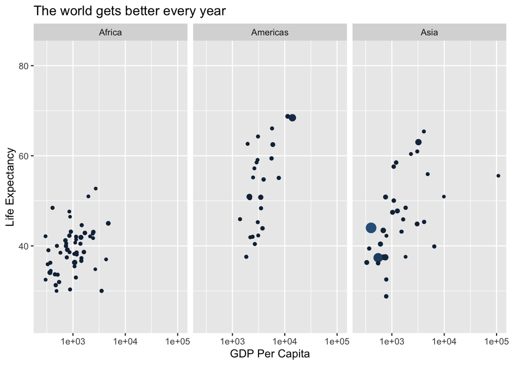